# ASML3 Lab 2 – Basic modelling in R

## Introduction

In this lab we will use two data sets to explore basic binary and multiclass classification models that we saw in lectures so far.

The first is a credit scoring dataset: an important application in banking. The data consist of 4454 observations of 14 variables, each a loan that was given together with the status of whether the loan was “good” (ie repaid) or went “bad” (ie defaulted).

```r
# Uncomment and run the following command first if you do not have the modeldata package
# install.packages("modeldata")
data("credit_data", package = "modeldata")
```

Use some of the exploration techniques from Lab 1 to explore the dataset before you start modelling.

```r
# Try some plotting function to explore the data here
```

The second dataset we will use which is multiclass is the famous MNIST handwriting data set. I have already put this data into the format we discussed in lectures for coding of images (an image per row with pixels as features). Download it first (this may take some time, it is ~40MB)

```r
# Uncomment and run the following command first if you do not have the fst package
# install.packages("fst")
download.file("http://www.louisaslett.com/Courses/MISCADA/mnist.fst", "mnist.fst")
mnist <- fst::read.fst("mnist.fst")
```

Have a look at this data. If you want to see an image, the following function will help plot any of the images for you. Read and try to understand the two lines involved by looking at the documentation for each step.

```r
library("tidyverse")
plotimages <- function(i) {
  imgs <- mnist %>%
    slice(i) %>%
    mutate(image.num = i) %>%
    pivot_longer(x0.y27:x27.y0,
                 names_to = c("x", "y"),
                 names_pattern = "x([0-9]{1,2}).y([0-9]{1,2})",
                 names_transform = list(x = as.integer, y = as.integer),
                 values_to = "greyscale")

  ggplot(imgs, aes(x = x, y = y, fill = greyscale)) +
    geom_tile() +
    scale_fill_gradient(low = "white", high = "black") +
    facet_wrap(~ image.num + response, labeller = label_both)
}
```

We can then look at the individual images, or groups of them. For example, to look at images 21 through 24, we run:

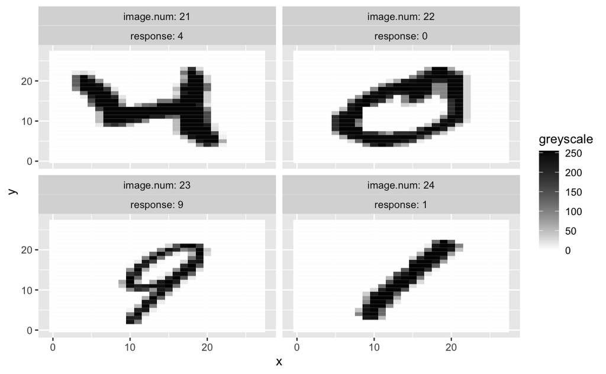

```r
plotimages(21:24)
```

## Base R linear methods for credit data

We saw a quick fit of logistic regression to the hotels data at the end of the last lab but it was a bit rushed! We’ll revisit logistic regression again here going more slowly and understanding the details for the banking data and then try LDA.

### Logistic regression

We can fit a standard logistic regression to the credit data using the `glm()` function in base R. Note that logistic regression is a special case of a family of models called Generalised Linear Models which arises from assuming a Binomially distributed response (we do not go into this mathematical detail in lectures), so we specify the `binomial` family argument.

```r
credit_fit <- glm(Status ~ ., binomial, credit_data)
```

You can inspect the fitted coefficients by looking at the object returned or get more detail (such as statistical tests of the coefficients, see ASML2) by passing the object to `summary()`.

```r
credit_fit
```

```
Call:  glm(formula = Status ~ ., family = binomial, data = credit_data)

Coefficients:
     (Intercept)         Seniority         Homeother         Homeowner       Homeparents
       8.120e-01         8.133e-02         3.441e-01         1.192e+00         9.770e-01
        Homepriv          Homerent              Time               Age    Maritalmarried
       4.799e-01         5.890e-01         4.233e-04        -8.831e-03         7.436e-01
Maritalseparated     Maritalsingle      Maritalwidow        Recordsyes      Jobfreelance
      -5.001e-01         3.316e-01         8.665e-02        -1.818e+00        -3.142e-01
       Jobothers        Jobpartime          Expenses            Income            Assets
      -6.661e-01        -1.511e+00        -1.818e-02         7.602e-03         2.703e-05
            Debt            Amount             Price
      -1.516e-04        -2.214e-03         1.065e-03

Degrees of Freedom: 4038 Total (i.e. Null);  4016 Residual
  (415 observations deleted due to missingness)
Null Deviance:      4578
Residual Deviance: 3364     AIC: 3410
```

```r
summary(credit_fit)
```

```
Call:
glm(formula = Status ~ ., family = binomial, data = credit_data)

Deviance Residuals:
    Min       1Q   Median       3Q      Max
-3.3081  -0.3161   0.3790   0.6525   2.4978

Coefficients:
                   Estimate Std. Error z value Pr(>|z|)
(Intercept)       8.120e-01  7.575e-01   1.072 0.283738
Seniority         8.133e-02  8.213e-03   9.902  < 2e-16 ***
Homeother         3.441e-01  5.859e-01   0.587 0.557025
Homeowner         1.192e+00  5.678e-01   2.100 0.035724 *
Homeparents       9.770e-01  5.776e-01   1.691 0.090742 .
Homepriv          4.799e-01  5.872e-01   0.817 0.413795
Homerent          5.890e-01  5.718e-01   1.030 0.303000
Time              4.233e-04  3.867e-03   0.109 0.912817
Age              -8.831e-03  5.444e-03  -1.622 0.104750
Maritalmarried    7.436e-01  4.389e-01   1.694 0.090210 .
Maritalseparated -5.001e-01  4.879e-01  -1.025 0.305277
Maritalsingle     3.316e-01  4.442e-01   0.746 0.455399
Maritalwidow      8.665e-02  5.519e-01   0.157 0.875243
Recordsyes       -1.818e+00  1.095e-01 -16.610  < 2e-16 ***
Jobfreelance     -3.142e-01  1.242e-01  -2.529 0.011440 *
Jobothers        -6.661e-01  2.220e-01  -3.000 0.002700 **
Jobpartime       -1.511e+00  1.299e-01 -11.631  < 2e-16 ***
Expenses         -1.818e-02  2.883e-03  -6.306 2.86e-10 ***
Income            7.602e-03  7.644e-04   9.946  < 2e-16 ***
Assets            2.703e-05  7.924e-06   3.412 0.000645 ***
Debt             -1.516e-04  4.283e-05  -3.540 0.000401 ***
Amount           -2.214e-03  1.954e-04 -11.331  < 2e-16 ***
Price             1.065e-03  1.476e-04   7.214 5.43e-13 ***
---
Signif. codes:  0 ‘***’ 0.001 ‘**’ 0.01 ‘*’ 0.05 ‘.’ 0.1 ‘ ’ 1

(Dispersion parameter for binomial family taken to be 1)

    Null deviance: 4577.9  on 4038  degrees of freedom
Residual deviance: 3364.2  on 4016  degrees of freedom
  (415 observations deleted due to missingness)
AIC: 3410.2

Number of Fisher Scoring iterations: 5
```

If we want to predict using this data we use the predict function.

```r
credit_pred <- predict(credit_fit, credit_data)
credit_pred
```

[output not shown]

[output cut: 232 more lines]

[output not shown]

These values might look a bit odd if you were expecting probabilities! By default, predict returns the *linear* part. If we want the probabilities we need to ask for the response:

```r
credit_pred <- predict(credit_fit, credit_data, type = "response")
credit_pred
```

[output not shown]

[output cut: 196 more lines]

[output not shown]

If we want to mimic the Bayes classifier, we then need to choose:

$$\hat{y} = \arg\max_k \mathbb{P}(Y = C_k | X = x)$$

But what are the $C_k$? It turns out that `glm()` assigns 0/1 to the factor levels in the order they are in the data.

```r
# Check the order ...
levels(credit_data$Status)
```

```
[1] "bad"  "good"
```

```r
# ... so "bad" = 0 and "good" = 1

# Now use this knowledge to set Bayes classifier prediction
y_hat <- factor(ifelse(credit_pred > 0.5, "good", "bad"))
```

Once we have this we can compute the accuracy of the classifier on the data:

```r
mean(I(y_hat == credit_data$Status))
```

```
[1] NA
```

What went wrong??

It turns out that there is missing data within the credit data and one of the limiting aspects of logistic regression is that it needs complete data to be able to make a prediction (otherwise what to multiply by the coefficient?). We will omit the missing predictions,

```r
mean(I(na.omit(y_hat == credit_data$Status)))
```

```
[1] 0.8120822
```

This compound estimate of accuracy is not very revealing. A much more insightful display is a confusion matrix:

```r
table(truth = na.omit(credit_data)$Status, prediction = na.omit(y_hat))
```

```
      prediction
truth   bad good
  bad   474  552
  good  207 2806
```

### Linear Discriminant Analysis

We can also try the first generative modelling approach we have seen in lectures, LDA. Printing the object after fitting reveals the class probabilities, group means, etc.

```r
credit_lda <- MASS::lda(Status ~ ., credit_data)
credit_lda
```

```
Call:
lda(Status ~ ., data = credit_data)

Prior probabilities of groups:
      bad      good
0.2540233 0.7459767

Group means:
     Seniority  Homeother Homeowner Homeparents   Homepriv  Homerent     Time      Age
bad   4.669591 0.09259259 0.3167641   0.1998051 0.07309942 0.3099415 49.38596 34.97173
good  9.333223 0.05443080 0.5326917   0.1712579 0.05044806 0.1875207 45.83936 37.62031
     Maritalmarried Maritalseparated Maritalsingle Maritalwidow Recordsyes Jobfreelance
bad       0.6608187       0.04775828     0.2631579   0.01559454  0.3352827    0.1608187
good      0.7540657       0.02090939     0.2027879   0.01526718  0.1055426    0.1808828
      Jobothers Jobpartime Expenses   Income   Assets     Debt    Amount    Price
bad  0.05458090 0.24951267 57.10624 121.1832 3343.019 334.3129 1143.6920 1436.451
good 0.03020246 0.05808165 55.39927 148.7322 5643.943 335.5486  991.5032 1454.116

Coefficients of linear discriminants:
                           LD1
Seniority         4.254105e-02
Homeother         2.264645e-01
Homeowner         9.131769e-01
Homeparents       7.427215e-01
Homepriv          3.861234e-01
Homerent          4.300013e-01
Time              6.742138e-04
Age              -6.588666e-03
Maritalmarried    5.233591e-01
Maritalseparated -4.643593e-01
Maritalsingle     2.278641e-01
Maritalwidow      1.024722e-01
Recordsyes       -1.540260e+00
Jobfreelance     -2.355588e-01
Jobothers        -6.533128e-01
Jobpartime       -1.629654e+00
Expenses         -1.257514e-02
Income            4.135544e-03
Assets            1.175091e-05
Debt             -8.412169e-05
Amount           -1.281371e-03
Price             4.848782e-04
```

We can again evaluate the fit. LDA is also unable to handle missing values, so we omit them.

```r
credit_pred <- predict(credit_lda, na.omit(credit_data))
credit_pred
```

[output not shown]

[output cut: 1552 more lines]

The accuracy now is:

```r
mean(I(credit_pred$class == na.omit(credit_data)$Status))
```

```
[1] 0.8066353
```

The confusion matrix in this case is:

```r
table(truth = na.omit(credit_data)$Status, prediction = credit_pred$class)
```

```
      prediction
truth   bad good
  bad   486  540
  good  241 2772
```

This feels rather unpleasant … it seems each model is going to have its own interface and its own method of outputting predictions. Whilst it is good to understand how to access these methods directly, since we are going to learn several more techniques over the coming lectures it would be annoying to have to learn separate interfaces for them all!

Fortunately, there are meta-packages which make life easier. The one we will look at here is called `mlr3` (https://mlr3.mlr-org.com) and is arguably the gold standard in machine learning meta-packages.

If you want to investigate more yourself, there are others: `caret` (http://topepo.github.io/caret/index.html) is a slightly older one. The authors of `caret` have now moved on to develop `tidymodels` (https://github.com/tidymodels) which is designed to supercede it, but it does not yet have all the functionality of `caret`. The old version of `mlr` (https://mlr.mlr-org.com) is still very good and has more functionality than has been brought into `mlr3` so far, but it will be out of date soon so we favour learning `mlr3` here.

## MLR 3

All of the above analysis can be done using `mlr3` as follows.

MLR breaks machine learning problems up into steps. The most basic ones are where you:

- define tasks
- define learners
- train learners on tasks
- predict from learners
- evaulate performance

### Credit data

To define the credit task, we provide the data and specify what is the target (response variable for learning).

```r
library("mlr3")

task_credit <- TaskClassif$new(id = "credit",
                               backend = na.omit(credit_data),
                               target = "Status")
task_credit
```

```
<TaskClassif:credit> (4039 x 14)
* Target: Status
* Properties: twoclass
* Features (13):
  - int (9): Age, Amount, Assets, Debt, Expenses, Income, Price, Seniority, Time
  - fct (4): Home, Job, Marital, Records
```

Then, we can see what learners MLR has built in.

```r
as.data.table(mlr_learners)
```

| key | feature_types | packages | properties | predict_types |
| --- | --- | --- | --- | --- |
| classif.debug |  |  |  |  |
| classif.featureless |  |  |  |  |
| classif.rpart |  |  |  |  |
| regr.featureless |  |  |  |  |
| regr.rpart |  |  |  |  |

This seems rather few! This is because additional packages are used to add features such as new learners. The staple learners are in the `mlr3learners` add on package, which then updates `mlr_learners` with a lot of additional options.

```r
library("mlr3learners")
library("mlr3proba")

as.data.table(mlr_learners)
```

| key | feature_types | packages | properties | predict_types |
| --- | --- | --- | --- | --- |
| classif.cv_glmnet |  |  |  |  |
| classif.debug |  |  |  |  |
| classif.featureless |  |  |  |  |
| classif.glmnet |  |  |  |  |
| classif.kknn |  |  |  |  |
| classif.lda |  |  |  |  |
| classif.log_reg |  |  |  |  |
| classif.multinom |  |  |  |  |
| classif.naive_bayes |  |  |  |  |
| classif.nnet |  |  |  |  |

[output cut: 24 more lines]

We will define a logistic regression learner.

```r
learner_lr <- lrn("classif.log_reg")
learner_lr
```

```
<LearnerClassifLogReg:classif.log_reg>
* Model: -
* Parameters: list()
* Packages: stats
* Predict Type: response
* Feature types: logical, integer, numeric, character, factor, ordered
* Properties: twoclass, weights
```

Then we train that learner on the credit data task.

```r
learner_lr$train(task_credit)
```

And then predict on the same data (see lecture why this is actually a bad idea!)

```r
pred <- learner_lr$predict(task_credit)
pred
```

```
<PredictionClassif> for 4039 observations:
```

| row_id | truth | response |
| --- | --- | --- |
| 1 | good | good |
| 2 | good | good |
| 3 | bad | bad |
| 4 | good | good |
| 5 | good | good |
| 6 | good | good |
| 7 | good | good |
| 8 | good | good |
| 9 | good | good |
| 10 | bad | bad |

[output cut: 990 more lines]

Finally, we can assess accuracy and confusion matrix by accessing this object.

```r
pred$score(msr("classif.acc"))
```

```
classif.acc
  0.8120822
```

```r
pred$confusion
```

```
        truth
response  bad good
    bad   474  207
    good  552 2806
```

There are many more ways to evaluate accuracy, some of which we’ll encounter in lectures. See the many MLR3 supports using this:

```r
mlr_measures
```

```
<DictionaryMeasure> with 98 stored values
Keys: classif.acc, classif.auc, classif.bacc, classif.bbrier, classif.ce,
  classif.costs, classif.dor, classif.fbeta, classif.fdr, classif.fn, classif.fnr,
  classif.fomr, classif.fp, classif.fpr, classif.logloss, classif.mbrier,
  classif.mcc, classif.npv, classif.ppv, classif.prauc, classif.precision,
  classif.recall, classif.sensitivity, classif.specificity, classif.tn, classif.tnr,
  classif.tp, classif.tpr, debug, dens.logloss, oob_error, regr.bias, regr.ktau,
  regr.mae, regr.mape, regr.maxae, regr.medae, regr.medse, regr.mse, regr.msle,
  regr.pbias, regr.rae, regr.rmse, regr.rmsle, regr.rrse, regr.rse, regr.rsq,
  regr.sae, regr.smape, regr.srho, regr.sse, selected_features, surv.beggC,
  surv.brier, surv.calib_alpha, surv.calib_beta, surv.chambless_auc,
  surv.chamblessAUC, surv.cindex, surv.gonenC, surv.graf, surv.grafSE, surv.harrellC,
  surv.hung_auc, surv.hungAUC, surv.intlogloss, surv.intloglossSE, surv.logloss,
  surv.loglossSE, surv.mae, surv.maeSE, surv.mse, surv.mseSE, surv.nagelk_r2,
  surv.nagelkR2, surv.oquigley_r2, surv.oquigleyR2, surv.rmse, surv.rmseSE,
  surv.schmid, surv.song_auc, surv.song_tnr, surv.song_tpr, surv.songAUC,
  surv.songTNR, surv.songTPR, surv.uno_auc, surv.uno_tnr, surv.uno_tpr, surv.unoAUC,
  surv.unoC, surv.unoTNR, surv.unoTPR, surv.xu_r2, surv.xuR2, time_both,
  time_predict, time_train
```

We can do the same for the LDA, this time with all the code at once for readability (we do not need to recreate the task).

```r
learner_lda <- lrn("classif.lda")

learner_lda$train(task_credit)

pred_lda <- learner_lda$predict(task_credit)

pred_lda$score(msr("classif.acc"))
```

```
classif.acc
  0.8066353
```

```r
pred_lda$confusion
```

```
        truth
response  bad good
    bad   486  241
    good  540 2772
```

Thus, a unified interface makes life a *lot* easier!

### MNIST

With this new-found ease of fitting, we can try a final quick experiment on the more exciting MNIST data. Note that this is a very large dataset, so for the purposes of the lab we are only going to use a random sample of 1000 images. You can try the bigger dataset on your own computer in your own time. We also need to set the response to be a factor because R loaded it as numbers.

```r
mnist <- mnist %>%
  slice(sample(length(response), 1000)) %>%
  mutate(response = as.factor(response))

task_mnist <- TaskClassif$new(id = "credit",
                              backend = mnist,
                              target = "response")

learner_glmnet <- lrn("classif.glmnet")

learner_glmnet$train(task_mnist)

pred_glmnet <- learner_glmnet$predict(task_mnist)

pred_glmnet$score(msr("classif.acc"))
```

```
classif.acc
      0.932
```

```r
pred_glmnet$confusion
```

```
        truth
response   0   1   2   3   4   5   6   7   8   9
       0  93   0   2   0   1   0   2   0   1   3
       1   0  98   1   0   0   1   0   2   3   2
       2   0   0  95   4   0   0   0   1   0   0
       3   1   0   0 109   0   4   0   0   3   1
       4   0   0   1   0  93   0   2   2   0   3
       5   1   0   0   2   2  72   0   0   1   2
       6   2   0   1   0   0   0  89   0   0   0
       7   0   0   0   0   1   0   0  97   0   0
       8   0   0   1   1   0   1   1   1  85   1
       9   1   0   0   2   4   1   0   0   2 101
```

Let’s look at an example of what an image it got wrong looks like. Try to understand how this code produces what you want.

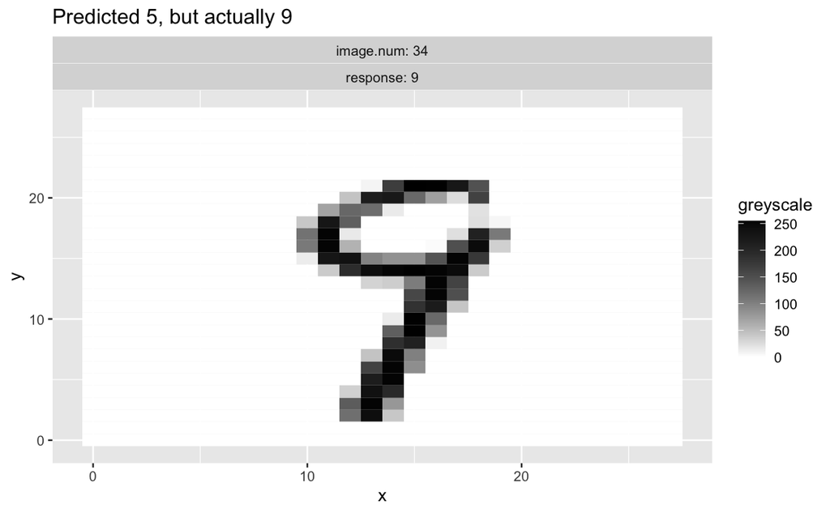

```r
wrong <- pred_glmnet$truth!=pred_glmnet$response

# Change i to look at different wrong predictions
i <- 2
plotimages(which(wrong)[i]) +
  ggtitle(glue::glue("Predicted {pred_glmnet$response[which(wrong)[i]]}, but actually {pred_glmnet$truth[which(wrong)[i]]}"))
```

Can you see how the algorithm might have been confused?

Next we can compare LDA …

```r
learner_lda <- lrn("classif.lda")

task_mnist <- TaskClassif$new(id = "credit",
                              backend = mnist,
                              target = "response")

#learner_lda$train(task_mnist) # NB this gives an error ... that is intended, see below!
```

We have a problem: some of the pixels are always the same colour (eg in the corners of the image there is never anything written) and this causes the covariance to be uncomputable there. We must first remove these features and then fit again.

```r
task_mnist <- TaskClassif$new(id = "credit",
                              backend = mnist %>%
                                select_if(function(x) {
                                  is.factor(x) || I(sd(x)>0)
                                }),
                              target = "response")

learner_lda$train(task_mnist)
```

```
variables are collinear
```

```r
pred_lda <- learner_lda$predict(task_mnist)

pred_lda$score(msr("classif.acc"))
```

```
classif.acc
      0.997
```

```r
pred_lda$confusion
```

```
        truth
response   0   1   2   3   4   5   6   7   8   9
       0  98   0   0   0   0   0   0   0   0   0
       1   0  98   0   0   0   0   0   1   0   0
       2   0   0 101   0   0   0   0   0   0   0
       3   0   0   0 118   0   0   0   0   0   0
       4   0   0   0   0 100   0   0   0   0   0
       5   0   0   0   0   0  79   0   0   0   0
       6   0   0   0   0   0   0  94   0   0   0
       7   0   0   0   0   0   0   0 101   0   0
       8   0   0   0   0   0   0   0   0  95   0
       9   0   0   0   0   1   0   0   1   0 113
```

And have a look at one LDA got wrong:

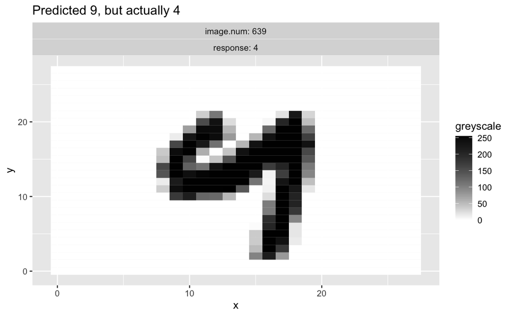

```r
wrong <- pred_lda$truth!=pred_lda$response

# Change i to look at different wrong predictions
i <- 2
plotimages(which(wrong)[i]) +
  ggtitle(glue::glue("Predicted {pred_lda$response[which(wrong)[i]]}, but actually {pred_lda$truth[which(wrong)[i]]}"))
```

# Wrap-up

What is the big thing wrong/missing in the above???

Yes, error estimation! We have not properly performed cross validation or some other method of correctly estimating the error … so we’ll be digging into that and construct a full pipeline for analysis in the next lab!